# Weekly Working Hours and Job Satisfaction Among UK Data Scientists

Safa A Elrais

21/05/2021

## Introduction :

### *Background*

Today, Data Science is one of the hottest Jobs in Technology with Data Scientists are among the highest paid with an average annual income of 140849£ in the UK. Sometimes the long working hours, the complexity of data problems, the high expectations from employees exert tremendous pressure on Data Scientists. The stressful nature of the job may affect the level of Job Satisfaction leading to many more Data Scientists leaving their jobs.

### *Research Questions*

By this Data Visualization, we aim to investigate :

1. The overall level of Satisfaction of UK Data Scientists.
2. HOw the level of Satisfaction is affected by weekly working hours.

### *Data Origins*

The data is sourced directly from [Stack Overflow Annual Developer Survey](https://insights.stackoverflow.com/survey/) for the year 2020. The survey was fielded from February 5 to February 28, 2020 , and top 5 sources of respondents were on site messaging, blog posts, email lists, Meta posts, banner ads, and social media posts. The Survey consists of 62 Question and a full version of the survey can be found [here](https://github.com/SafaElrais/Tensorflow-Survey-/blob/main/survey_questions.pdf)

```r
datafile= "C:/Users/44751/OneDrive/Desktop/200266165/PSYC6422/2020_tensorflow_survey.csv"  # this loads the data

df0 <- read.csv(datafile)

head(df0,5)       #this displays the first 5 rows of the data
```

```
##   Respondent                                               MainBranch Hobbyist
## 1          1                           I am a developer by profession      Yes
## 2          2                           I am a developer by profession       No
## 3          3                              I code primarily as a hobby      Yes
## 4          4                           I am a developer by profession      Yes
## 5          5 I used to be a developer by profession, but no longer am      Yes
##   Age Age1stCode CompFreq CompTotal ConvertedComp            Country
## 1  NA         13  Monthly        NA            NA            Germany
## 2  NA         19     <NA>        NA            NA     United Kingdom
## 3  NA         15     <NA>        NA            NA Russian Federation
## 4  25         18     <NA>        NA            NA            Albania
## 5  31         16     <NA>        NA            NA      United States
##     CurrencyDesc CurrencySymbol DatabaseDesireNextYear
## 1  European Euro            EUR   Microsoft SQL Server
## 2 Pound sterling            GBP                   <NA>
```

[output cut: 177 more lines]

The analysis focuses mainly on 4 variables , the following table provides each variable names and its explanation.

| Variable.name | Explanation |
| --- | --- |
| Gender | Either Man , Woman , Non-Binary |
| Country | Counrty where respondent currently lives |
| JobSat | Level of satisfaction as 5 likert scale of satisfaction |
| WorkWeekHrs | How many hours does the respondent work per week |

## Data cleaning and Preparation :

Thinking of the visualisation, I am going to create, our data set needs to go through several steps of date filtering, variables selection, and data cleaning before it is ready to plot.

The following chunk of code is required :

```r
# loading the required libraries

library(dplyr)
library(outliers)

# filtering , selecting and removing missing values from the dataset


df <- df0 %>%

  filter(Country == "United Kingdom", Gender == "Man" | Gender == "Woman") %>%   # this Subsets Data Frame only retaining Man and Women responses from United kingdom
  select("Gender","Country","JobSat","WorkWeekHrs") %>%   # this Subsets Data frame to include the specific  variables for our analysis

  na.omit(df)   # this removes the missing values from data frame


# removing outlier values from WorkWeekHrs column using the quantiles method

Q1 <- quantile(df$WorkWeekHrs, .25)                           # this calculates the Q1

Q3 <- quantile(df$WorkWeekHrs, .75)                           # this calculates the Q3

IQR <- IQR(df$WorkWeekHrs)                                    # this calculates the interquantile range


clean_df<- subset(df, df$WorkWeekHrs> (Q1 - 1.5*IQR) & df$WorkWeekHrs< (Q3 + 1.5*IQR)) # this subsets data frame and retain only data between (Q1 - 1.5*IQR) and (Q3 + 1.5*IQR)


head(clean_df,5)                                              #this shows the first 5 rows of the processed dataframe
```

```
##   Gender        Country                JobSat WorkWeekHrs
## 1    Man United Kingdom        Very satisfied          36
## 2    Man United Kingdom Slightly dissatisfied          40
## 4    Man United Kingdom Slightly dissatisfied          37
## 5    Man United Kingdom    Slightly satisfied          40
## 6    Man United Kingdom        Very satisfied          40
```

```r
summary(clean_df)                                             #this shows summary statistics
```

```
##     Gender            Country             JobSat           WorkWeekHrs
##  Length:2171        Length:2171        Length:2171        Min.   :33.00
##  Class :character   Class :character   Class :character   1st Qu.:37.00
##  Mode  :character   Mode  :character   Mode  :character   Median :38.00
##                                                           Mean   :38.42
##                                                           3rd Qu.:40.00
##                                                           Max.   :44.00
```

## Data Visualization :

### *Visualization 1 : The overall level Of Satisfaction Among Data Scientists*

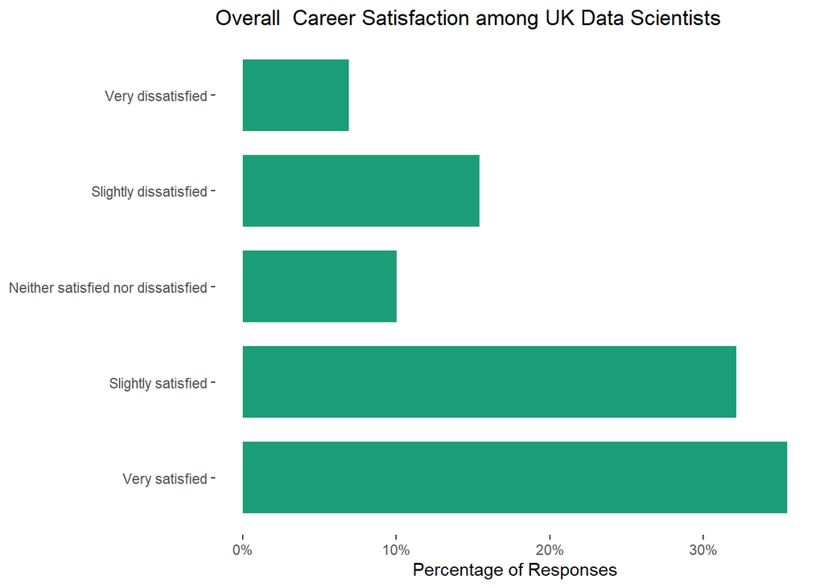

```r
# labeling the parameter of the graph

title <- "Overall  Career Satisfaction among UK Data Scientists "

ylab <- "Percentage of Responses"


# setting the limits for x-axis

x_limits <- c("Very satisfied",
              "Slightly satisfied",
              "Neither satisfied nor dissatisfied",
              "Slightly dissatisfied",
              "Very dissatisfied")


# drawing a bar graph with JobSatisfaction on X-axis and percentages of responses on y-axis then flip the coordinates

library(ggplot2)

figure1 <- ggplot(data=clean_df, mapping = aes(x=JobSat, fill= "JobSat"))

figure1 + geom_bar(mapping = aes(y=..prop..,group="JobSat"), width = 0.75)+labs(y =ylab,
                                                                                title = title)+
                                                                          scale_x_discrete(limits=x_limits)+
                                                                          scale_y_continuous(labels = scales::percent)+coord_flip()+
                                                                          theme(legend.position = "none",
                                                                                 panel.background = element_blank(),
                                                                                 axis.title.y = element_blank())+
                                                                           scale_fill_brewer(palette = "Dark2")
```

```r
# save the plot

library(here)

ggsave(here("figures","Overall level of Satisfaction.png"))
```

### *Visualization 2 :Weekly Working Hours and Job Satisfaction*

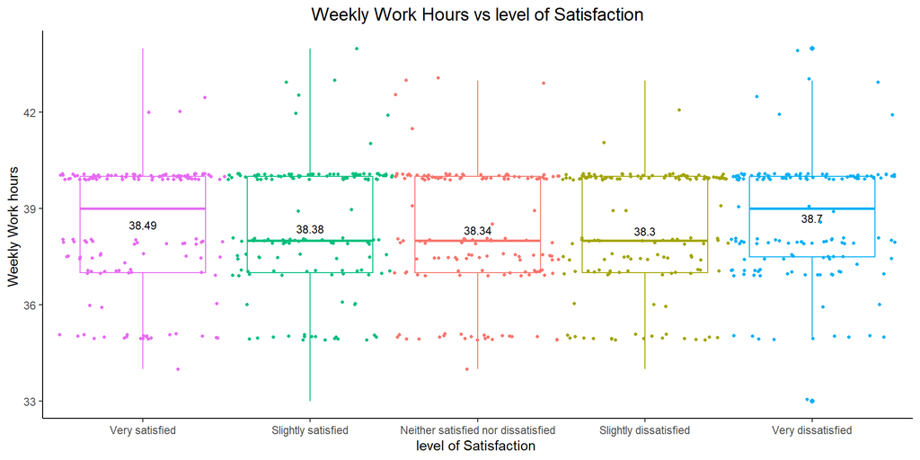

```r
#labeling the parameters of the graph

title <- " Weekly Work Hours vs level of Satisfaction "
xlab <- "level of Satisfaction "
ylab <- "Weekly Work hours "
y_breaks <- c(30,33,36,39,42,45)


# calculating the mean values of box plot groups

summary_df <- clean_df %>%
  group_by(JobSat) %>%
  summarise(means=mean(WorkWeekHrs))


# drawing a box-plot with geom_jitter with JobSatisfaction on X-axis and and Weekly Working hours on Y-axis , and adding mean values as text on every box-plot

figure2 <- ggplot(data=clean_df,mapping = aes(x=JobSat , y=WorkWeekHrs, color = JobSat))

figure2+geom_boxplot()+ geom_text(data=summary_df, aes(y=means, label=round(means,2)),
                                size= 3,color='black',position=position_dodge(0.8))+
                        geom_jitter(data = clean_df %>% group_by(JobSat) %>% sample_n(150),position = position_jitter(0.5),size = 0.9)+
                        labs(title = title,
                             x=xlab,
                             y=ylab)+
                        scale_x_discrete(limits=x_limits)+
                        scale_y_continuous(breaks = y_breaks)+theme(legend.position = "none",
                                                                plot.title=element_text(size=14,
                                                                             hjust=0.5),
                                                               axis.line.x = element_line(size = 0.5, colour="black"),
                                                               axis.line.y = element_line(size = 0.5, colour = "black"),
                                                               axis.line = element_line(size=1, colour = "black"),
                                                               panel.grid.major = element_blank(),
                                                               panel.grid.minor = element_blank(),
                                                               panel.border = element_blank(),
                                                               panel.background = element_blank())+scale_fill_brewer(palette = "Dark2")
```

```r
# save the plot

ggsave(here("figures","Working Hours vs level of Satisfaction.png"))
```

## Summary :

The Dataset is very voluminous. With the time constraints, It was only possible to Visualize responses collected from the United Kingdom Data Scientists. By looking at the first graph, We can conclude that the Majority ( ~ 67%) of participants were either partially or very Satisfied with their Jobs. The complex nature of the tasks required in this field may lead to more time spent working. We may anticipate that long working hours will affect the level of satisfaction, and those who worked longer hours would report a lower level of Job Satisfaction, but when we look at the box plot, we see that the different groups of Job Satisfaction actually worked almost the same average of hours per week with the slightly higher average for those who were very dissatisfied. This may lead us to question what could be the more impactful factor on Job Satisfaction among UK Data Scientists. The Survey collected Data about other factors, and it would be more informative to explore the effect of these factors, such as Annual income, Organization size, Gender differences and Age, in relation to all of the factors. Furthermore, any further comparison would be more useful if it took into consideration the satisfaction level of other countries participants.